# Восстановление золота из руды

**Цель проекта: оптимизации производственных расходов золоторудного комбината**

**Задача проекта: создать модель для предсказаания коэффициента восстановления золота из золотосодержащей руды. Модель поможет оптимизировать производство, чтобы не запускать предприятие с убыточными характеристиками.**

Данные

В нашем распоряжении имеются данные с параметрами добычи и очистки.

Данные находятся в трёх файлах:

```
gold_recovery_train.csv — обучающая выборка;
gold_recovery_test.csv — тестовая выборка;
gold_recovery_full.csv — исходные данные.
```

Данные индексируются датой и временем получения информации (признак date). В тестовой выборке отсутствуют некоторые признаки, которые могут быть в обучающей. Также в тестовом наборе нет целевых признаков. Исходный датасет содержит обучающую и тестовую выборки со всеми признаками.

Наименование признаков строится по следующему правилу:

[этап].[тип_параметра].[название_параметра]

Пример: final.output.concentrate_au

Возможные значения для блока [этап]:

```
rougher — флотация
primary_cleaner — первичная очистка
secondary_cleaner — вторичная очистка
final — финальные характеристики
```

Возможные значения для блока [тип_параметра]:

```
input — параметры сырья
output — параметры продукта
state — параметры, характеризующие текущее состояние этапа
calculation — расчётные характеристики
```

**План работы**

- **Загрузить библиотеки**
  > - Потребуются библиотеки pandas, matplotlib, sklearn
- **Подготовка данных**
> - Открыть и изучить файлы.
> - Провести предобработку данных. Убрать или заменить пропуски, привести данные к нужным типам.
> - Проверить, что эффективность обогащения рассчитана правильно. Вычислить её на обучающей выборке для признака rougher.output.recovery. Найти MAE между расчитанным и имеющимся значением признака. Описать выводы.
> - Проанализировать признаки, недоступные в тестовой выборке. Что это за параметры? К какому типу относятся?
- **Проанализировать данные**
> - Изучить, как меняется концентрация металлов (Au, Ag, Pb) на различных этапах очистки. Описать выводы.
> - Сравнить распределения размеров гранул сырья на обучающей и тестовой выборках. Если распределения сильно отличаются друг от друга, оценка модели будет неправильной.
> - Исследовать суммарную концентрацию всех веществ на разных стадиях: в сырье, в черновом и финальном концентратах. Проверить, есть ли аномальные значения в суммарном распределении. Определить, если они есть, следует ли их удалять из обеих выборок? Описать выводы и удалить аномалии в соответствии с принятыми правилами, если найдутся.
- **Построить модель**
> - Написать функцию для вычисления итоговой sMAPE.
> - Обучить разные модели и оценить их качество кросс-валидацией.
> - Выбрать лучшую модель и проверить её на тестовой выборке.
> - Описать выводы.

## Используемые библиотеки

```python
import pandas as pd
import matplotlib.pyplot as plt
import numpy as np
import warnings
import catboost as cb

from sklearn.tree import DecisionTreeRegressor
from sklearn.ensemble import RandomForestRegressor
from sklearn.linear_model import LinearRegression
from sklearn.model_selection import train_test_split
from sklearn.metrics import mean_squared_error
from sklearn.metrics import mean_absolute_error

from sklearn.metrics import precision_recall_curve
from sklearn.tree import DecisionTreeClassifier
from sklearn.metrics import accuracy_score
from sklearn.metrics import mean_squared_error
from sklearn.metrics import roc_auc_score
from sklearn.metrics import f1_score
from sklearn.utils import shuffle
from sklearn.preprocessing import StandardScaler
from sklearn.model_selection import cross_val_score
from sklearn.metrics import make_scorer
from sklearn.model_selection import RepeatedStratifiedKFold
from sklearn.dummy import DummyRegressor
from sklearn.metrics import mean_squared_error, r2_score, median_absolute_error
from sklearn.ensemble import IsolationForest

from catboost import *
from catboost import datasets
from catboost import CatBoostRegressor
from catboost import Pool, cv
```

```python
warnings.filterwarnings('ignore')
pd.set_option('display.max_columns', None)#Снимаем ограничения по кол-ву выводимых на экран столбцов
```

## Подготовка данных

### Загрузка данных

```python
name_df = ['Обучающая выборка', 'Тестовая выборка', 'Исходные данные']
cvs = ['gold_recovery_train_new.csv', 'gold_recovery_test_new.csv',
       'gold_recovery_full_new.csv']
df = [[], [], []] #Переменная для сохранения данных
```

### Обзор данных

```python
for i in [0, 1, 2]:
    df[i] = pd.read_csv(cvs[i])

    print(name_df[i])
    print(df[i].head())
    print(df[i].tail())
    df[i].info()
    print('Явных дубликатов = ', df[i].duplicated().sum())# Явных дубликатов нет
    #data = data.drop_duplicates(keep='first')#  Удаляем явные дубликаты, оставляя первые значения
    print()
```

```
Обучающая выборка
                  date  final.output.concentrate_ag  \
0  2016-01-15 00:00:00                     6.055403
1  2016-01-15 01:00:00                     6.029369
2  2016-01-15 02:00:00                     6.055926
3  2016-01-15 03:00:00                     6.047977
4  2016-01-15 04:00:00                     6.148599

   final.output.concentrate_pb  final.output.concentrate_sol  \
0                     9.889648                      5.507324
1                     9.968944                      5.257781
2                    10.213995                      5.383759
3                     9.977019                      4.858634
4                    10.142511                      4.939416

```

[output cut: 2377 more lines]

Обучающая выборка date final.output.concentrate_ag \ 0 2016-01-15 00:00:00 6.055403  
1 2016-01-15 01:00:00 6.029369  
2 2016-01-15 02:00:00 6.055926  
3 2016-01-15 03:00:00 6.047977  
4 2016-01-15 04:00:00 6.148599

```
               date  final.output.concentrate_ag  \
```

14144 2018-08-18 06:59:59 3.224920  
14145 2018-08-18 07:59:59 3.195978  
14146 2018-08-18 08:59:59 3.109998  
14147 2018-08-18 09:59:59 3.367241  
14148 2018-08-18 10:59:59 3.598375

Тестовая выборка date primary_cleaner.input.sulfate \ 0 2016-09-01 00:59:59 210.800909  
1 2016-09-01 01:59:59 215.392455  
2 2016-09-01 02:59:59 215.259946  
3 2016-09-01 03:59:59 215.336236  
4 2016-09-01 04:59:59 199.099327

```
              date  primary_cleaner.input.sulfate  \
```

5285 2017-12-31 19:59:59 173.957757  
5286 2017-12-31 20:59:59 172.910270  
5287 2017-12-31 21:59:59 171.135718  
5288 2017-12-31 22:59:59 179.697158  
5289 2017-12-31 23:59:59 181.556856

Исходные данные date final.output.concentrate_ag \ 0 2016-01-15 00:00:00 6.055403  
1 2016-01-15 01:00:00 6.029369  
2 2016-01-15 02:00:00 6.055926  
3 2016-01-15 03:00:00 6.047977  
4 2016-01-15 04:00:00 6.148599

```
               date  final.output.concentrate_ag  \
```

19434 2018-08-18 06:59:59 3.224920  
19435 2018-08-18 07:59:59 3.195978  
19436 2018-08-18 08:59:59 3.109998  
19437 2018-08-18 09:59:59 3.367241  
19438 2018-08-18 10:59:59 3.598375

Данные разбиты на выборки следующим образом.

С 2016-01-15 00:00:00 до 2016-09-01 00:59:59 - Обучающая выборка;

Далее с 2016-09-01 00:59:59 по 2017-12-31 23:59:59 - Тестоваяая выборка;

И с 2018-01-01 00:00:00 по 2018-08-18 10:59:59 - опять Обучающая выборка.

### Проверка рассчётных параметров

#### Функция для рассчёта эффективности обогащения

По определению эффективности обогащения составим функцию для её вычисления в %:

```python
def Recovery(c, f, t):
    return c*(f-t)/(f*(c-t))*100
```

#### Проверка - 1

Проверим, что эффективность обогащения рассчитана правильно на стадии rougher.output. Вычислим её на обучающей и на исходной выборке для признака rougher.output.recovery. Найдём MAE между нашими расчётами и значением признака. Опишим выводы.

```python
res_rougher = [] # Расчитанный нами целевой признак "rougher.output.recovery"

for i in df[0].index:# Для обучающей выборки
    res_rougher.append(Recovery(df[0]['rougher.output.concentrate_au'][i], df[0]['rougher.input.feed_au'][i],
                       df[0]['rougher.output.tail_au'][i]))
display(res_rougher[0:5])
print("MAE на обучающей выборке: ", mean_absolute_error(df[0]['rougher.output.recovery'], res_rougher))
```

```
[87.10776292825425,
 86.84326050586625,
 86.84230825746626,
 87.22642953304764,
 86.68879413602453]
```

```
MAE на обучающей выборке:  9.730101616170628e-15
```

```python
res_rougher = [] # Расчитанный нами целевой признак "rougher.output.recovery"

for i in df[2].index:# Для исходной выборки
    res_rougher.append(Recovery(df[2]['rougher.output.concentrate_au'][i], df[2]['rougher.input.feed_au'][i],
                       df[2]['rougher.output.tail_au'][i]))
display(res_rougher[0:5])
print("MAE на исходной выборке: ", mean_absolute_error(df[2]['rougher.output.recovery'], res_rougher))
```

```
[87.10776292825425,
 86.84326050586625,
 86.84230825746626,
 87.22642953304764,
 86.68879413602453]
```

```
MAE на исходной выборке:  9.871121473701021e-15
```

**Вывод**

> MAE на обучающей выборке относительно рассчитанного нами 1 * 10 в "-14" степени.

> Точность высокая

> Эффективность обогащения на стадии rougher.output. рассчитана правильно.

#### Проверка - 2

Проверим, что эффективность обогащения рассчитана правильно на стадии final.output. Вычислим её на обучающей выборке для признака final.output.recovery.

```python
res_final = [] # Расчитанный нами целевой признак "final.output.recovery"

for i in df[0].index:# Для обучающей выборки
    res_final.append(Recovery(df[0]['final.output.concentrate_au'][i], df[0]['rougher.output.concentrate_au'][i],
                       df[0]['final.output.tail_au'][i]))
display(res_final[0:5])
display(df[0]['final.output.recovery'][0:5])
```

```
[93.94455351393717,
 93.7905006809621,
 93.50975013540881,
 93.59526777079917,
 93.81197603506968]
```

```
0    70.541216
1    69.266198
2    68.116445
3    68.347543
4    66.927016
Name: final.output.recovery, dtype: float64
```

**Вывод**

| № | Признак final.output.recovery | Расчётное значение |
| --- | --- | --- |
| 0 | 70.541216 | 93.94455351393717 |
| 1 | 69.266198 | 93.7905006809621 |
| 2 | 68.116445 | 93.50975013540881 |
| 3 | 68.347543 | 93.59526777079917 |
| 4 | 66.927016 | 93.81197603506968 |

> Эффективность обогащения для признака final.output.recovery не совпала с расчётной.

## Анализ данных

### Соответствие между признаками Тестовой и Обучающей выборками

#### Проанализируем признаки, недоступные в тестовой выборке. Что это за параметры? К какому типу относятся?

```python
print("Параметры  отсутствующие в массиве", name_df[1])
print()
for j in df[0].columns:# Для столбцов "Обучающей выборки"
    if j not in df[1].columns:# Выявим столбцы отсутствующие в массиве 'Тестовая выборка'
        print(j)
```

```
Параметры  отсутствующие в массиве Тестовая выборка

final.output.concentrate_ag
final.output.concentrate_pb
final.output.concentrate_sol
final.output.concentrate_au
final.output.recovery
final.output.tail_ag
final.output.tail_pb
final.output.tail_sol
final.output.tail_au
primary_cleaner.output.concentrate_ag
primary_cleaner.output.concentrate_pb
primary_cleaner.output.concentrate_sol
primary_cleaner.output.concentrate_au
primary_cleaner.output.tail_ag
primary_cleaner.output.tail_pb
primary_cleaner.output.tail_sol
primary_cleaner.output.tail_au
rougher.calculation.sulfate_to_au_concentrate
rougher.calculation.floatbank10_sulfate_to_au_feed
rougher.calculation.floatbank11_sulfate_to_au_feed
rougher.calculation.au_pb_ratio
rougher.output.concentrate_ag
rougher.output.concentrate_pb
rougher.output.concentrate_sol
rougher.output.concentrate_au
rougher.output.recovery
rougher.output.tail_ag
rougher.output.tail_pb
rougher.output.tail_sol
rougher.output.tail_au
secondary_cleaner.output.tail_ag
secondary_cleaner.output.tail_pb
secondary_cleaner.output.tail_sol
secondary_cleaner.output.tail_au
```

#### Вывод

**В Тестовой выборке отсутствуют:**

> - параметры концентрации продуктов в сырье после флотации/очистки,
> - параметры концентрации продуктов в хвостах после флотации/очистки,
> - расчётные параметры "recovery",
> - расчётные характеристики флотации:
> - rougher.calculation.sulfate_to_au_concentrate
> - rougher.calculation.floatbank10_sulfate_to_au_feed
> - rougher.calculation.floatbank11_sulfate_to_au_feed
> - rougher.calculation.au_pb_ratio

#### Удаление из массива "Обучающая выборка" колонок отсутствующих в массиве 'Тестовая выборка'

Удалим из массива "Обучающая выборка" колонки отсутствующие в массиве 'Тестовая выборка'. Обоснование - нет смысла обучать модель на тех признаках которые она не сможет анализировать при тестировании.

```python
for j in df[0].columns:# Для столбцов
    if j not in df[1].columns:# Выявим столбцы отсутствующие в массиве 'Тестовая выборка'
        df[0].drop(j, axis= 1 , inplace= True ) # Удалим столбцы отсутствующие в массиве 'Тестовая выборка'
```

### Удаление столбцов `date`

Удалим столбцы `date`, так как они не информативны для дальнейшей работы.

```python
for i in [0, 1, 2]:
    df[i].drop('date', axis=1, inplace= True ) # Удалим столбцы 'date' во всех массивах
    df[i] = df[i].astype('float32')# Изменяем тип данных float64 -> float32
```

### Пропуски в данных

#### Знакомимся с пропусками в данных

```python
for i in [0, 1, 2]:
    print(name_df[i])
    display(pd.DataFrame(round(df[i].isna().mean()*100,)).style.background_gradient('coolwarm'))
```

```
Обучающая выборка
```

|  | 0 |
| --- | --- |
| primary_cleaner.input.sulfate | 0.000000 |
| primary_cleaner.input.depressant | 0.000000 |
| primary_cleaner.input.feed_size | 0.000000 |
| primary_cleaner.input.xanthate | 1.000000 |
| primary_cleaner.state.floatbank8_a_air | 0.000000 |
| primary_cleaner.state.floatbank8_a_level | 0.000000 |
| primary_cleaner.state.floatbank8_b_air | 0.000000 |
| primary_cleaner.state.floatbank8_b_level | 0.000000 |
| primary_cleaner.state.floatbank8_c_air | 0.000000 |
| primary_cleaner.state.floatbank8_c_level | 0.000000 |
| primary_cleaner.state.floatbank8_d_air | 0.000000 |
| primary_cleaner.state.floatbank8_d_level | 0.000000 |
| rougher.input.feed_ag | 0.000000 |
| rougher.input.feed_pb | 1.000000 |
| rougher.input.feed_rate | 0.000000 |
| rougher.input.feed_size | 1.000000 |
| rougher.input.feed_sol | 1.000000 |
| rougher.input.feed_au | 0.000000 |
| rougher.input.floatbank10_sulfate | 0.000000 |
| rougher.input.floatbank10_xanthate | 0.000000 |
| rougher.input.floatbank11_sulfate | 0.000000 |
| rougher.input.floatbank11_xanthate | 3.000000 |
| rougher.state.floatbank10_a_air | 0.000000 |
| rougher.state.floatbank10_a_level | 0.000000 |
| rougher.state.floatbank10_b_air | 0.000000 |
| rougher.state.floatbank10_b_level | 0.000000 |
| rougher.state.floatbank10_c_air | 0.000000 |
| rougher.state.floatbank10_c_level | 0.000000 |
| rougher.state.floatbank10_d_air | 0.000000 |
| rougher.state.floatbank10_d_level | 0.000000 |
| rougher.state.floatbank10_e_air | 3.000000 |
| rougher.state.floatbank10_e_level | 0.000000 |
| rougher.state.floatbank10_f_air | 0.000000 |
| rougher.state.floatbank10_f_level | 0.000000 |
| secondary_cleaner.state.floatbank2_a_air | 2.000000 |
| secondary_cleaner.state.floatbank2_a_level | 0.000000 |
| secondary_cleaner.state.floatbank2_b_air | 0.000000 |
| secondary_cleaner.state.floatbank2_b_level | 0.000000 |
| secondary_cleaner.state.floatbank3_a_air | 0.000000 |
| secondary_cleaner.state.floatbank3_a_level | 0.000000 |
| secondary_cleaner.state.floatbank3_b_air | 0.000000 |
| secondary_cleaner.state.floatbank3_b_level | 0.000000 |
| secondary_cleaner.state.floatbank4_a_air | 0.000000 |
| secondary_cleaner.state.floatbank4_a_level | 0.000000 |
| secondary_cleaner.state.floatbank4_b_air | 0.000000 |
| secondary_cleaner.state.floatbank4_b_level | 0.000000 |
| secondary_cleaner.state.floatbank5_a_air | 0.000000 |
| secondary_cleaner.state.floatbank5_a_level | 0.000000 |
| secondary_cleaner.state.floatbank5_b_air | 0.000000 |
| secondary_cleaner.state.floatbank5_b_level | 0.000000 |
| secondary_cleaner.state.floatbank6_a_air | 0.000000 |
| secondary_cleaner.state.floatbank6_a_level | 0.000000 |

```
Тестовая выборка
```

|  | 0 |
| --- | --- |
| primary_cleaner.input.sulfate | 0.000000 |
| primary_cleaner.input.depressant | 0.000000 |
| primary_cleaner.input.feed_size | 0.000000 |
| primary_cleaner.input.xanthate | 0.000000 |
| primary_cleaner.state.floatbank8_a_air | 0.000000 |
| primary_cleaner.state.floatbank8_a_level | 0.000000 |
| primary_cleaner.state.floatbank8_b_air | 0.000000 |
| primary_cleaner.state.floatbank8_b_level | 0.000000 |
| primary_cleaner.state.floatbank8_c_air | 0.000000 |
| primary_cleaner.state.floatbank8_c_level | 0.000000 |
| primary_cleaner.state.floatbank8_d_air | 0.000000 |
| primary_cleaner.state.floatbank8_d_level | 0.000000 |
| rougher.input.feed_ag | 0.000000 |
| rougher.input.feed_pb | 0.000000 |
| rougher.input.feed_rate | 0.000000 |
| rougher.input.feed_size | 0.000000 |
| rougher.input.feed_sol | 0.000000 |
| rougher.input.feed_au | 0.000000 |
| rougher.input.floatbank10_sulfate | 0.000000 |
| rougher.input.floatbank10_xanthate | 0.000000 |
| rougher.input.floatbank11_sulfate | 0.000000 |
| rougher.input.floatbank11_xanthate | 0.000000 |
| rougher.state.floatbank10_a_air | 0.000000 |
| rougher.state.floatbank10_a_level | 0.000000 |
| rougher.state.floatbank10_b_air | 0.000000 |
| rougher.state.floatbank10_b_level | 0.000000 |
| rougher.state.floatbank10_c_air | 0.000000 |
| rougher.state.floatbank10_c_level | 0.000000 |
| rougher.state.floatbank10_d_air | 0.000000 |
| rougher.state.floatbank10_d_level | 0.000000 |
| rougher.state.floatbank10_e_air | 0.000000 |
| rougher.state.floatbank10_e_level | 0.000000 |
| rougher.state.floatbank10_f_air | 0.000000 |
| rougher.state.floatbank10_f_level | 0.000000 |
| secondary_cleaner.state.floatbank2_a_air | 0.000000 |
| secondary_cleaner.state.floatbank2_a_level | 0.000000 |
| secondary_cleaner.state.floatbank2_b_air | 0.000000 |
| secondary_cleaner.state.floatbank2_b_level | 0.000000 |
| secondary_cleaner.state.floatbank3_a_air | 0.000000 |
| secondary_cleaner.state.floatbank3_a_level | 0.000000 |
| secondary_cleaner.state.floatbank3_b_air | 0.000000 |
| secondary_cleaner.state.floatbank3_b_level | 0.000000 |
| secondary_cleaner.state.floatbank4_a_air | 0.000000 |
| secondary_cleaner.state.floatbank4_a_level | 0.000000 |
| secondary_cleaner.state.floatbank4_b_air | 0.000000 |
| secondary_cleaner.state.floatbank4_b_level | 0.000000 |
| secondary_cleaner.state.floatbank5_a_air | 0.000000 |
| secondary_cleaner.state.floatbank5_a_level | 0.000000 |
| secondary_cleaner.state.floatbank5_b_air | 0.000000 |
| secondary_cleaner.state.floatbank5_b_level | 0.000000 |
| secondary_cleaner.state.floatbank6_a_air | 0.000000 |
| secondary_cleaner.state.floatbank6_a_level | 0.000000 |

```
Исходные данные
```

|  | 0 |
| --- | --- |
| final.output.concentrate_ag | 0.000000 |
| final.output.concentrate_pb | 0.000000 |
| final.output.concentrate_sol | 1.000000 |
| final.output.concentrate_au | 0.000000 |
| final.output.recovery | 0.000000 |
| final.output.tail_ag | 0.000000 |
| final.output.tail_pb | 1.000000 |
| final.output.tail_sol | 0.000000 |
| final.output.tail_au | 0.000000 |
| primary_cleaner.input.sulfate | 0.000000 |
| primary_cleaner.input.depressant | 0.000000 |
| primary_cleaner.input.feed_size | 0.000000 |
| primary_cleaner.input.xanthate | 1.000000 |
| primary_cleaner.output.concentrate_ag | 0.000000 |
| primary_cleaner.output.concentrate_pb | 1.000000 |
| primary_cleaner.output.concentrate_sol | 2.000000 |
| primary_cleaner.output.concentrate_au | 0.000000 |
| primary_cleaner.output.tail_ag | 0.000000 |
| primary_cleaner.output.tail_pb | 0.000000 |
| primary_cleaner.output.tail_sol | 0.000000 |
| primary_cleaner.output.tail_au | 0.000000 |
| primary_cleaner.state.floatbank8_a_air | 0.000000 |
| primary_cleaner.state.floatbank8_a_level | 0.000000 |
| primary_cleaner.state.floatbank8_b_air | 0.000000 |
| primary_cleaner.state.floatbank8_b_level | 0.000000 |
| primary_cleaner.state.floatbank8_c_air | 0.000000 |
| primary_cleaner.state.floatbank8_c_level | 0.000000 |
| primary_cleaner.state.floatbank8_d_air | 0.000000 |
| primary_cleaner.state.floatbank8_d_level | 0.000000 |
| rougher.calculation.sulfate_to_au_concentrate | 0.000000 |

[output cut: 56 more lines]

**Пропуски в данных**

#### Удаление пропусков в данных

```python
for i in [0, 1, 2]: # Из всех выборок:
    n=len(df[i])
    df[i].dropna(inplace=True) # Удалим строки с пропусками и сохраним изменения
    print('Из df[',i, ']удалено', n - len(df[i]), 'строк')
```

```
Из df[ 0 ]удалено 1470 строк
Из df[ 1 ]удалено 61 строк
Из df[ 2 ]удалено 3345 строк
```

### Анализ концентрации металлов на разных стадиях

Посмотрим, как меняется концентрация металлов (Au, Ag, Pb) на различных этапах очистки. Опишим выводы.

#### Концентрация золота

```python
print('au')
for j in ['final.output.concentrate_au', 'primary_cleaner.output.concentrate_au', 'rougher.output.concentrate_au',
          'rougher.input.feed_au']:
    print(df[2][j][0:5])
print()

for j in ['final.output.tail_au', 'secondary_cleaner.output.tail_au', 'primary_cleaner.output.tail_au',
          'rougher.output.tail_au', 'rougher.input.feed_au']:
    print(df[2][j][0:5])
```

```
au
0    42.192020
1    42.701630
2    42.657501
3    42.689819
4    42.774139
Name: final.output.concentrate_au, dtype: float32
0    34.174427
1    34.118526
2    33.969463
3    28.260742
4    33.044933
Name: primary_cleaner.output.concentrate_au, dtype: float32
0    19.793808
1    20.050976
```

[output cut: 41 more lines]

#### Концентрация серебра

```python
print('ag')
for j in ['final.output.concentrate_ag', 'primary_cleaner.output.concentrate_ag', 'rougher.output.concentrate_ag',
          'rougher.input.feed_ag']:
    print(df[2][j][0:5])
print()

for j in ['final.output.tail_ag', 'secondary_cleaner.output.tail_ag', 'primary_cleaner.output.tail_ag',
          'rougher.output.tail_ag', 'rougher.input.feed_ag']:
    print(df[2][j][0:5])
```

```
ag
0    6.055403
1    6.029368
2    6.055926
3    6.047977
4    6.148599
Name: final.output.concentrate_ag, dtype: float32
0    8.547551
1    8.558743
2    8.603505
3    7.221879
4    9.089428
Name: primary_cleaner.output.concentrate_ag, dtype: float32
0    11.500771
1    11.615865
```

[output cut: 41 more lines]

#### Концентрация свинца

```python
print('pb')
for j in ['final.output.concentrate_pb', 'primary_cleaner.output.concentrate_pb', 'rougher.output.concentrate_pb',
          'rougher.input.feed_pb']:
    print(df[2][j][0:5])
print()

for j in ['final.output.tail_pb', 'secondary_cleaner.output.tail_pb', 'primary_cleaner.output.tail_pb',
          'rougher.output.tail_pb', 'rougher.input.feed_pb']:
    print(df[2][j][0:5])
```

```
pb
0     9.889648
1     9.968945
2    10.213995
3     9.977018
4    10.142511
Name: final.output.concentrate_pb, dtype: float32
0    10.389648
1    10.497069
2    10.354494
3     8.496563
4     9.986786
Name: primary_cleaner.output.concentrate_pb, dtype: float32
0    7.101074
1    7.278807
```

[output cut: 41 more lines]

#### Графики концентрации при очистке

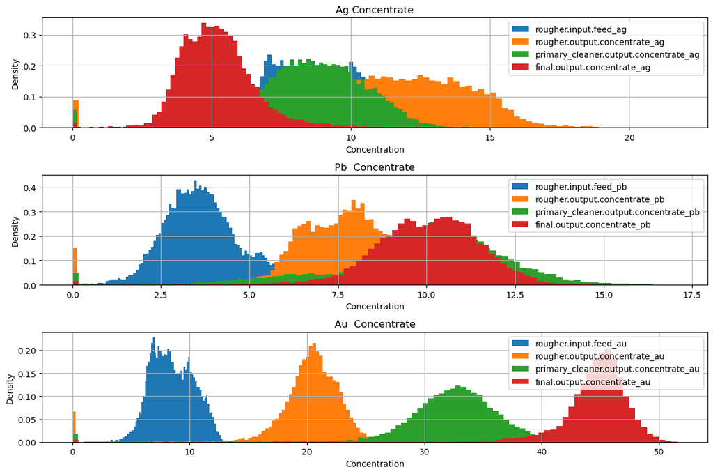

```python
fig, ax = plt.subplots(3, 1, figsize=(12, 8))
ax[0].set_title('Ag Concentrate')
ax[0].hist(df[2]['rougher.input.feed_ag'], density=True, bins=100, label='rougher.input.feed_ag')
ax[0].hist(df[2]['rougher.output.concentrate_ag'], density=True, bins=100, label='rougher.output.concentrate_ag')
ax[0].hist(df[2]['primary_cleaner.output.concentrate_ag'], density=True, bins=100,
           label='primary_cleaner.output.concentrate_ag')
ax[0].hist(df[2]['final.output.concentrate_ag'], density=True, bins=100, label='final.output.concentrate_ag')
ax[0].set_ylabel('Density')
ax[0].set_xlabel('Concentration')
ax[0].legend()
ax[0].grid(True)

ax[1].set_title('Pb  Concentrate')
ax[1].hist(df[2]['rougher.input.feed_pb'], density=True, bins=100, label='rougher.input.feed_pb')
ax[1].hist(df[2]['rougher.output.concentrate_pb'], density=True, bins=100, label='rougher.output.concentrate_pb')
ax[1].hist(df[2]['primary_cleaner.output.concentrate_pb'], density=True, bins=100,
           label='primary_cleaner.output.concentrate_pb')
ax[1].hist(df[2]['final.output.concentrate_pb'], density=True, bins=100, label='final.output.concentrate_pb')
ax[1].set_ylabel('Density')
ax[1].set_xlabel('Concentration')
ax[1].legend()
ax[1].grid(True)

ax[2].set_title('Au  Concentrate')
ax[2].hist(df[2]['rougher.input.feed_au'], density=True, bins=100, label='rougher.input.feed_au')
ax[2].hist(df[2]['rougher.output.concentrate_au'], density=True, bins=100, label='rougher.output.concentrate_au')
ax[2].hist(df[2]['primary_cleaner.output.concentrate_au'], density=True, bins=100,
           label='primary_cleaner.output.concentrate_au')
ax[2].hist(df[2]['final.output.concentrate_au'], density=True, bins=100, label='final.output.concentrate_au')
ax[2].set_ylabel('Density')
ax[2].set_xlabel('Concentration')
ax[2].legend()
ax[2].grid(True)

fig.tight_layout()
fig.show()
```

#### Графики концентрации в отвалах

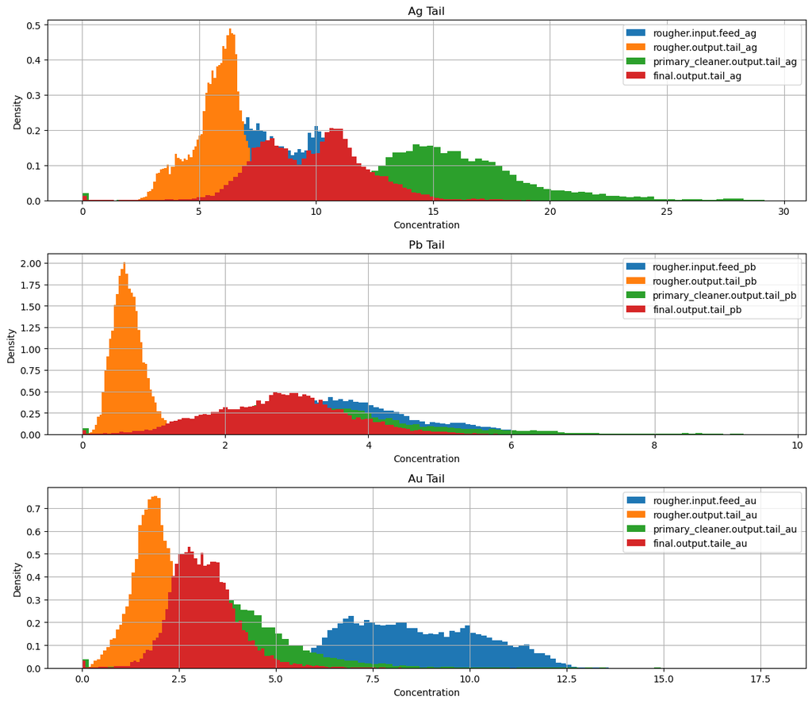

```python
fig, ax = plt.subplots(3, 1, figsize=(12, 10.5))
ax[0].set_title('Ag Tail')
ax[0].hist(df[2]['rougher.input.feed_ag'], density=True, bins=100, label='rougher.input.feed_ag')
ax[0].hist(df[2]['rougher.output.tail_ag'], density=True, bins=100, label='rougher.output.tail_ag')
ax[0].hist(df[2]['primary_cleaner.output.tail_ag'], density=True, bins=100, label='primary_cleaner.output.tail_ag')
ax[0].hist(df[2]['final.output.tail_ag'], density=True, bins=100, label='final.output.tail_ag')
ax[0].set_ylabel('Density')
ax[0].set_xlabel('Concentration')
ax[0].legend()
ax[0].grid(True)

ax[1].set_title('Pb Tail')
ax[1].hist(df[2]['rougher.input.feed_pb'], density=True, bins=100, label='rougher.input.feed_pb')
ax[1].hist(df[2]['rougher.output.tail_pb'], density=True, bins=100, label='rougher.output.tail_pb')
ax[1].hist(df[2]['primary_cleaner.output.tail_pb'], density=True, bins=100, label='primary_cleaner.output.tail_pb')
ax[1].hist(df[2]['final.output.tail_pb'], density=True, bins=100, label='final.output.tail_pb')
ax[1].set_ylabel('Density')
ax[1].set_xlabel('Concentration')
ax[1].legend()
ax[1].grid(True)

ax[2].set_title('Au Tail')
ax[2].hist(df[2]['rougher.input.feed_au'], density=True, bins=100, label='rougher.input.feed_au')
ax[2].hist(df[2]['rougher.output.tail_au'], density=True, bins=100, label='rougher.output.tail_au')
ax[2].hist(df[2]['primary_cleaner.output.tail_au'], density=True, bins=100, label='primary_cleaner.output.tail_au')
ax[2].hist(df[2]['final.output.tail_au'], density=True, bins=100, label='final.output.taile_au')
ax[2].set_ylabel('Density')
ax[2].set_xlabel('Concentration')
ax[2].legend()
ax[2].grid(True)

fig.tight_layout()
fig.show()
```

**Вывод**

> Концентрация серебра увеличивается только при флотации с 6 (руда) до 11,5, а при очистках последовательно снижается до 6 (конечный результат). Максимальная концентрация серебра в отвалах - 16 (после первой очистки).

> Концентрация свинца увеличивается при флотации и первой очистке с 2 (руда) до 10. Максимальная концентрация свинца в отвалах - 4,5 (после второй очистки).

> По логике производственного процесса концентрация золота должна увеличивается на каждом этапе производства. Если это не так, то вероятно мы имеем дело с ошибкой в данных и такие строки нужно удалить.

#### Удалим строки, если концентрация золота уменьшается на любом этапе производства

```python
print('au')
n = 0
for i in df[2].index:# Выявим строки в массиве Исходная выборка с уменьшающейся концентрацией золота
        if df[2]['final.output.concentrate_au'][i] > df[2]['primary_cleaner.output.concentrate_au'][i] > df[2][
            'rougher.output.concentrate_au'][i] > df[2]['rougher.input.feed_au'][i] > 0:
             pass
        else:
            df[2].drop(i, inplace=True)# Удалим строки
            n+=1
print('Из df[2]удалено', n, 'строк')
```

```
au
Из df[2]удалено 820 строк
```

### Исследуем суммарную концентрацию всех веществ на разных стадиях: в сырье, в черновом и финальном концентратах.

Просуммируем концентрацию au, ag, pb на четырёх стадиях final.output, primary_cleaner.output, rougher.output, rougher.input. Выбор данных организуем таким образом что бы не учитывать строки с неполными данными.

```python
res = []
count = 0
break_out_flag = False
for i in df[2].index:
    r = []
    for j in ['final.output.concentrate_au', 'final.output.concentrate_ag', 'final.output.concentrate_pb']:#, 'final.output.concentrate_sol'
        if df[2][j][i] > 0:
            count += df[2][j][i]
        else:
            count = 0
            break_out_flag = True
            break
    if break_out_flag:
        break
    else:
        r.append(count)
        count = 0
    for j in ['primary_cleaner.output.concentrate_au', 'primary_cleaner.output.concentrate_ag', 'primary_cleaner.output.concentrate_pb']:#, 'primary_cleaner.output.concentrate_sol'
        if df[2][j][i] > 0:
            count += df[2][j][i]
        else:
            count = 0
            break_out_flag = True
            break
    if break_out_flag:
        break
    else:
        r.append(count)
        count = 0
    for j in ['rougher.output.concentrate_au', 'rougher.output.concentrate_ag', 'rougher.output.concentrate_pb']:#, 'rougher.output.concentrate_sol'
        if df[2][j][i] > 0:
            count += df[2][j][i]
        else:
            count = 0
            break_out_flag = True
            break
    if break_out_flag:
        break
    else:
        r.append(count)
        count = 0
    for j in ['rougher.input.feed_au', 'rougher.input.feed_ag', 'rougher.input.feed_pb']:#, 'rougher.input.feed_sol'
        if df[2][j][i] > 0:
            count += df[2][j][i]
        else:
            count = 0
            break_out_flag = True
            break
    if break_out_flag:
        break
    else:
        r.append(count)
        count = 0
    res.append(r)
```

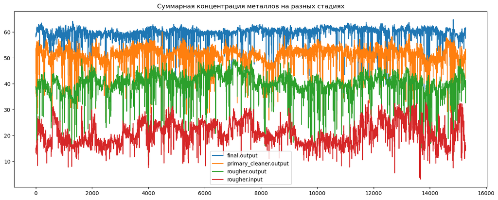

```python
#Сформируем данные в датафрейм
data = pd.DataFrame(res, columns = ['final.output', 'primary_cleaner.output', 'rougher.output', 'rougher.input'])
data.plot(legend= True, figsize=(16, 6), title = 'Суммарная концентрация металлов на разных стадиях');
```

**Вывод**

> Суммарная концентрация металлов в ходе производственного процесса последовательно увеличивается.

### Коэффициенты обогащения

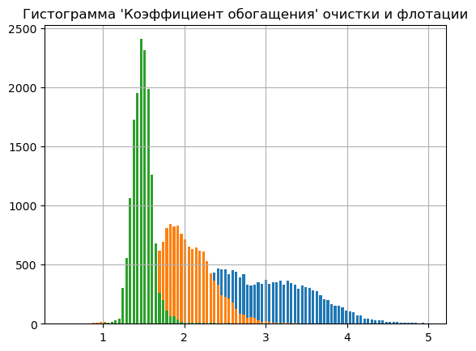

```python
#Рассчитаем коэффициенты обогащения суммарного содержания металлов на разных стадиях производственного процесса.
data.insert (loc= len(data.columns) , column='roug_fin', value=data['final.output']/data['rougher.input'])
data.insert (loc= len(data.columns) , column='roug_float', value=data['rougher.output']/data['rougher.input'])
data.insert (loc= len(data.columns) , column='float_fin', value=data['final.output']/data['rougher.output'])

data['roug_fin'].hist(bins=100, rwidth= .7, range = (0.5, 5)); # Коэффициент обогащения всего произв-го процесса
data['roug_float'].hist(bins=100, rwidth= .7, range = (0.5, 5)); # Коэффициент обогащения при флотации
data['float_fin'].hist(bins=100, rwidth= .7, range = (0.5 , 5)); # Коэффициент обогащения при очистке
plt.title("Гистограмма 'Коэффициент обогащения' очистки и флотации");
```

**Вывод**

> - Коэффициент обогащения всего производственного процесса (среднее) - 3.
> - Коэффициент обогащения при флотации (среднее) - 2.
> - Коэффициент обогащения при очистке (среднее) - 1.5.
> - Интересный факт - иногда флотация протекает значительно эффективней (2.2 против 1.8). Перспективным будет провести исследование в этом направлении.

### Различие размеров гранул сырья на обучающей и тестовой выборках

#### Сравние средних и медианных размеров гранул сырья на обучающей и тестовой выборках

Сравним распределения размеров гранул сырья на обучающей и тестовой выборках. Если распределения сильно отличаются друг от друга, оценка модели будет неправильной.

```python
for i in [0, 1]:
    print(name_df[i])
    print('Среднее значение "rougher.input.feed_size":', df[i]['rougher.input.feed_size'].mean())
    print('Медианное значение "rougher.input.feed_size":', df[i]['rougher.input.feed_size'].median())
    print()

print("Различие средних значений", (df[0]['rougher.input.feed_size'].mean() - df[1]['rougher.input.feed_size'].mean()
      )/df[0]['rougher.input.feed_size'].mean()*100)
print("Различие медианных значений", (df[0]['rougher.input.feed_size'].median() - df[1][
    'rougher.input.feed_size'].median())/df[0]['rougher.input.feed_size'].median()*100)
```

```
Обучающая выборка
Среднее значение "rougher.input.feed_size": 58.41441
Медианное значение "rougher.input.feed_size": 54.651126861572266

Тестовая выборка
Среднее значение "rougher.input.feed_size": 55.86398
Медианное значение "rougher.input.feed_size": 50.772727966308594

Различие средних значений 4.366097971796989
Различие медианных значений 7.096649452603974
```

Сравние средних и медианных размеров гранул сырья на обучающей и тестовой выборках показало различие в 4 и 7% соответственно. Сильным различием это не является. Выборка была бы адекватней, если бы была выполненна случайным образом, а не подряд.

Необходимо рассмотреть распределение данного параметра.

#### Распределение размеров гранул сырья на обучающей и тестовой выборках

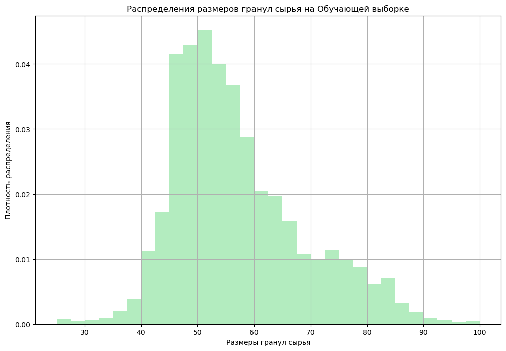

```python
df[0]['rougher.input.feed_size'].plot(kind='hist',
        density=True,
        alpha=0.8,
        bins=30,
        title='Распределения размеров гранул сырья на Обучающей выборке',
        rot=0,
        range = (25, 100),
        grid=True,
        figsize=(12,8),
        fontsize=10,
        color=['#A0E8AF'])
plt.xlabel('Размеры гранул сырья')
plt.ylabel("Плотность распределения");
```

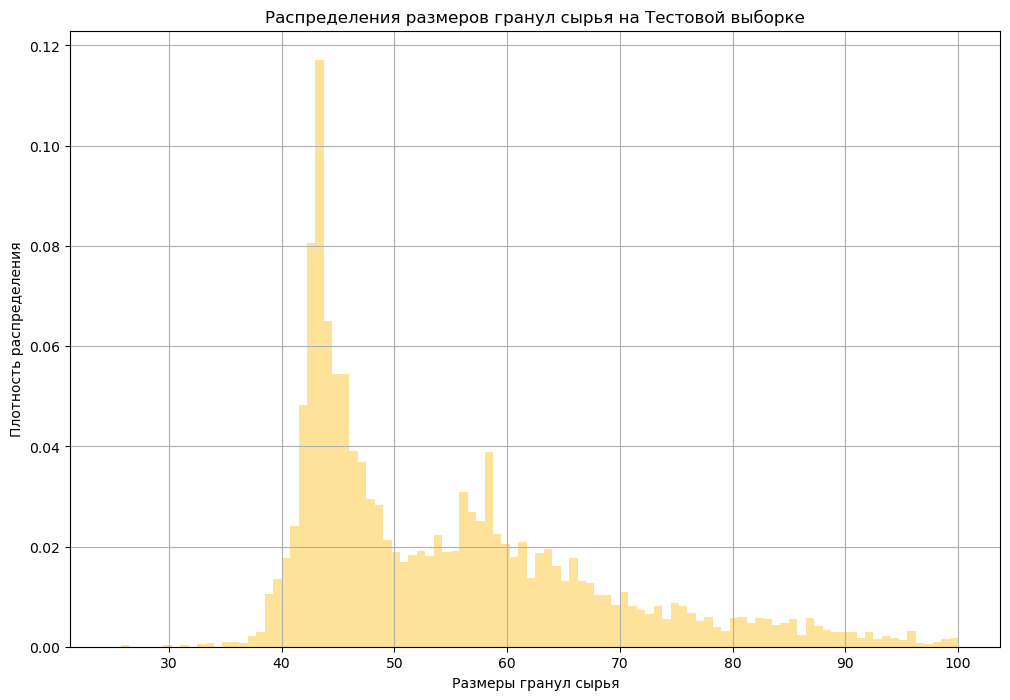

```python
df[1]['rougher.input.feed_size'].plot(kind='hist',
        density=True,
        alpha=0.6,
        bins=100,
        title='Распределения размеров гранул сырья на Тестовой выборке',
        rot=0,
        range = (25, 100),
        grid=True,
        figsize=(12,8),
        fontsize=10,
        color=['#FFCF56'])
plt.xlabel('Размеры гранул сырья')
plt.ylabel("Плотность распределения");
```

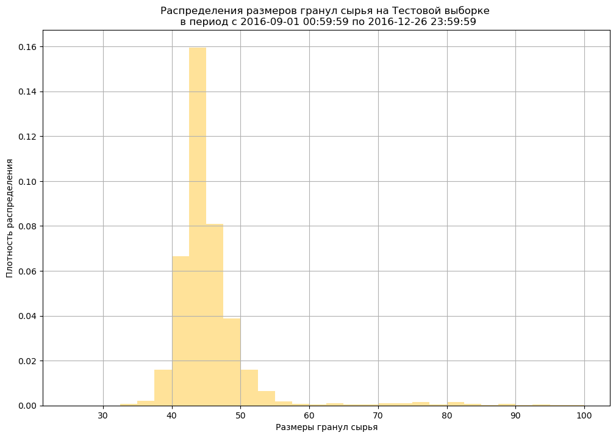

```python
df[1]['rougher.input.feed_size'][0:2500].plot(kind='hist',
        density=True,
        alpha=0.6,
        bins=30,
        title='Распределения размеров гранул сырья на Тестовой выборке \n в период с 2016-09-01 00:59:59 по 2016-12-26 23:59:59',
        rot=0,
        range = (25, 100),
        grid=True,
        figsize=(12,8),
        fontsize=10,
        color=['#FFCF56'])
plt.xlabel('Размеры гранул сырья')
plt.ylabel("Плотность распределения");
```

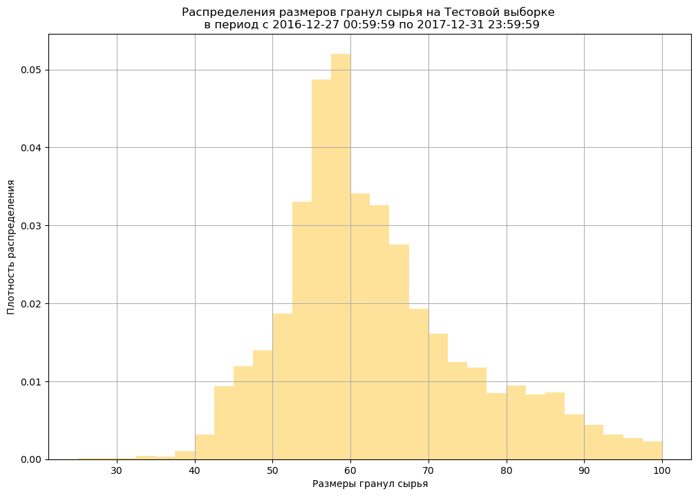

```python
df[1]['rougher.input.feed_size'][2500:].plot(kind='hist',
        density=True,
        alpha=0.6,
        bins=30,
        title='Распределения размеров гранул сырья на Тестовой выборке \n в период с 2016-12-27 00:59:59 по 2017-12-31 23:59:59',
        rot=0,
        range = (25, 100),
        grid=True,
        figsize=(12,8),
        fontsize=10,
        color=['#FFCF56'])
plt.xlabel('Размеры гранул сырья')
plt.ylabel("Плотность распределения");
```

```python
# Добавим в Тестовую и Обучающую выборку столбец 'rougher.input.feed_clas'.
# Заполним данные столбцы значениями 0, если 'rougher.input.feed_size' <= 50 и значением 1 в противном случае.

for i in [0, 1]:
    df[i]['rougher.input.feed_clas'] = 0
    for j in df[i].index:
        if df[i]['rougher.input.feed_size'][j] > 50:
            df[i]['rougher.input.feed_clas'][j] = 1

df[0]['rougher.input.feed_clas'] = df[0]['rougher.input.feed_clas'].astype('bool')
df[1]['rougher.input.feed_clas'] = df[1]['rougher.input.feed_clas'].astype('bool')
df[0].info()
```

```
<class 'pandas.core.frame.DataFrame'>
Int64Index: 12679 entries, 0 to 14148
Data columns (total 53 columns):
 #   Column                                      Non-Null Count  Dtype
---  ------                                      --------------  -----
 0   primary_cleaner.input.sulfate               12679 non-null  float32
 1   primary_cleaner.input.depressant            12679 non-null  float32
 2   primary_cleaner.input.feed_size             12679 non-null  float32
 3   primary_cleaner.input.xanthate              12679 non-null  float32
 4   primary_cleaner.state.floatbank8_a_air      12679 non-null  float32
 5   primary_cleaner.state.floatbank8_a_level    12679 non-null  float32
 6   primary_cleaner.state.floatbank8_b_air      12679 non-null  float32
 7   primary_cleaner.state.floatbank8_b_level    12679 non-null  float32
 8   primary_cleaner.state.floatbank8_c_air      12679 non-null  float32
 9   primary_cleaner.state.floatbank8_c_level    12679 non-null  float32
```

[output cut: 45 more lines]

**Вывод**

### Анализ целевых признаков

#### Подозрительные значения среди 'final.output.recovery'

Рассмотрим первый целевой параметр 'final.output.recovery' в Исходной выборке.

```
count    15274.000000
mean        67.671692
std          7.668699
min          8.406898
25%         63.882337
50%         68.279182
75%         72.562090
max        100.000000
Name: final.output.recovery, dtype: float64
```

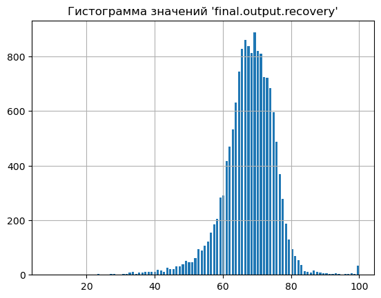

```python
df[2]['final.output.recovery'].hist(bins=100, rwidth= .7)
plt.title("Гистограмма значений 'final.output.recovery'");
df[2]['final.output.recovery'].describe()
```

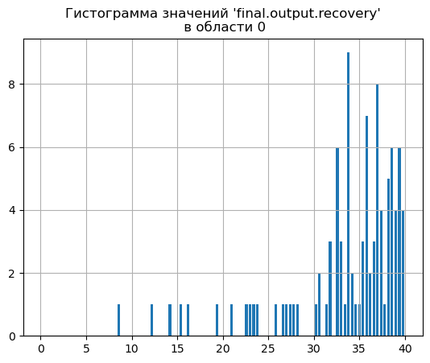

```python
df[2]['final.output.recovery'].hist(bins=100, rwidth= .7, range = (0, 40));
plt.title("Гистограмма значений 'final.output.recovery'\n в области 0");
```

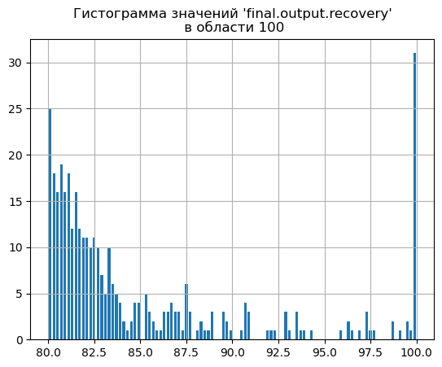

```python
df[2]['final.output.recovery'].hist(bins=100, rwidth= .7, range = (80, 100))
plt.title("Гистограмма значений 'final.output.recovery'\n в области 100");
```

Значения df[2]['final.output.recovery'] менее 25 и больше 90 выглядят подозрительно. Удалим их .

#### Подозрительные значения среди 'rougher.output.recovery'

Рассмотрим второй целевой параметр 'rougher.output.recovery' в Исходной выборке.

```
count    15274.000000
mean        85.119392
std          6.850039
min          2.520854
25%         81.566526
50%         86.197716
75%         89.713219
max         99.979042
Name: rougher.output.recovery, dtype: float64
```

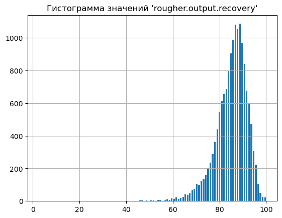

```python
df[2]['rougher.output.recovery'].hist(bins=100, rwidth= .7)
plt.title("Гистограмма значений 'rougher.output.recovery'");
df[2]['rougher.output.recovery'].describe()
```

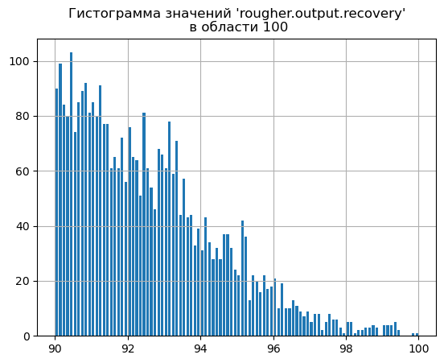

```python
df[2]['rougher.output.recovery'].hist(bins=100, rwidth= .7, range = (90, 100))
plt.title("Гистограмма значений 'rougher.output.recovery'\n в области 100");
```

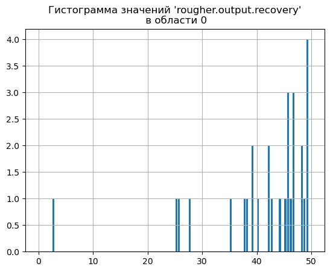

```python
df[2]['rougher.output.recovery'].hist(bins=100, rwidth= .7, range = (0, 50))
plt.title("Гистограмма значений 'rougher.output.recovery'\n в области 0");
```

Распределение значений df[2]['rougher.output.recovery'] выглядит достоверно.

#### Удаление подозрительных значений среди 'final.output.recovery' и 'rougher.output.recovery'

```python
# Удалим из Исходной выборки строки с параметрами 'final.output.recovery' меньше 25 или больше 90
n=0
for i in df[2].index:
    if (df[2]['final.output.recovery'][i] < 25) or (df[2]['final.output.recovery'][i] > 90):
        df[2] = df[2].drop(index= i)
        n+=1
print('Из df[2]удалено', n, 'строк')
```

```
Из df[2]удалено 79 строк
```

### Подготовка целевых признаков

- Добавим в Обучающую и Тестовую выборки два столбца 'final.output.recovery' и 'rougher.output.recovery'.
- Заполним данные столбцы соответствующими значениями из Исходных данных.
- Удалим из Обучающей и Тестовой выборок строки, если они отсутствуют в Исходных данных.

```python
for j in [0, 1]:
    df[j]['final.output.recovery'], df[j]['rougher.output.recovery'] = True, True
    n = 0
    for i in df[j].index:
        if i not in df[2].index:# Выявим строки отсутствующие в массиве 'Исходная выборка'
            df[j].drop(i, inplace=True)# Удалим отсутствующие строки
            n+=1
        else:
            df[j]['final.output.recovery'].loc[i] = df[2]['final.output.recovery'].loc[i]
            df[j]['rougher.output.recovery'].loc[i] = df[2]['rougher.output.recovery'].loc[i]
    print("Из df[", j, "] удалено", n, "строк")
    df[j]['final.output.recovery'] = df[j]['final.output.recovery'].astype('float32')
    df[j]['rougher.output.recovery'] = df[j]['rougher.output.recovery'].astype('float32')
```

```
Из df[ 0 ] удалено 1491 строк
Из df[ 1 ] удалено 675 строк
```

## Модель

**План**

> - Напишим функцию для вычисления итоговой sMAPE
> - Обучим разные модели и оценим их качество кросс-валидацией
> - Выберем лучшую модель и проверем её на тестовой выборке
> - Опишем выводы.

### Функция для вычисления итоговой sMAPE

```python
# Функция для рассчёта метрики качества — sMAPE (Symmetric Mean Absolute Percentage Error,
# «симметричное среднее абсолютное процентное отклонение»).

def sMAPE(zn, pr):
    return round(np.mean(np.abs(zn - pr)/(np.abs(zn) + np.abs(pr)))*100/2, 3)
```

### Обучим разные модели и оценим их качество кросс-валидацией

#### Формирование тренировочных и валидационных выборок

```python
# Для массива "Обучающая выборка" выделим целевые признаки и сформируем тренировочные и валидационные выборки

features = df[0].drop(['final.output.recovery','rougher.output.recovery'], axis=1)# удалим колонки с целевыми
# признаками
target_final = df[0]['final.output.recovery']# целевой признак
target_rougher = df[0]['rougher.output.recovery']# целевой признак
```

#### Функция кросс-валидации

```python
def Mean_score_mini(model, features, target):
    scores = []
    sample_size = int(len(df[0])/3)# зададим размер блока, если их всего три
    valid_indexes, train_indexes = [], []

    for i in range(0, int(len(df[0])), sample_size):
        valid_indexes = df[0].index[i:i+sample_size]# < массив из индексов для валидационного блока >
        train_indexes = [x for x in df[0].index if x not in valid_indexes]# < массив из индексов для обучающей
        # выборки >
        features_train, target_train = features.loc[train_indexes, :], target.loc[train_indexes]
        features_valid, target_valid = features.loc[valid_indexes, :], target.loc[valid_indexes]

        mean_model = model.fit(features_train, target_train)# Обучим модель для предсказаний
        # финального результата 'final.output.recovery'
        predicted_valid = mean_model.predict(features_valid)
        score = sMAPE(target_valid, predicted_valid)# Оценим качество модели
        scores.append(score)

    return  round(np.mean(scores),3), mean_model # Посчитаем среднее качество модели по итогам  кросс-валидации
```

#### Модель Дерево

```python
# Модель Дерево_Финал

best_model_final = None
best_result_final = 10000
best_depth_final = 0

for depth in range(1, 8):
    model = DecisionTreeRegressor(random_state=12345, max_depth=depth)# инициализируем модель DecisionTreeRegressor
    mean_score_final, model_final = Mean_score_mini(model, features, target_final)# Запустим модель
    #посредством функции кросс-валидации
    if mean_score_final < best_result_final:
        best_model_final = model_final
        best_result_final = mean_score_final
        best_depth_final = depth

print(" Модель Дерево. sMAPE_final:", best_result_final, "Глубина дерева:", best_depth_final)
```

```
 Модель Дерево. sMAPE_final: 2.244 Глубина дерева: 6
```

Модель Дерево. sMAPE_final: 2.278 Глубина дерева: 5

```python
# Модель Дерево_Флотация

best_model_rougher = None
best_result_rougher = 10000
best_depth_rougher = 0

for depth in range(1, 8):
    model = DecisionTreeRegressor(random_state=12345, max_depth=depth)# инициализируем модель
    # DecisionTreeRegressor с параметром random_state=12345 и max_depth=depth
    mean_score_rougher, model_rougher = Mean_score_mini(model, features, target_rougher)# Запустим модель
    # посредством функции кросс-валидации
    if mean_score_rougher < best_result_rougher:
        best_model_rougher = model_rougher
        best_result_rougher = mean_score_rougher
        best_depth_rougher = depth

print(" Модель Дерево. sMAPE_rougher:", best_result_rougher, "Глубина дерева:", best_depth_rougher)
```

```
 Модель Дерево. sMAPE_rougher: 1.59 Глубина дерева: 4
```

Модель Дерево. sMAPE_rougher: 1.591 Глубина дерева: 4

#### Модель Линейная регрессия

```python
# Модель Линейная регрессия_Финал

model = LinearRegression() # инициализируем модель LinearRegression
best_result_final, best_model_final = Mean_score_mini(model, features, target_final)# Запустим модель посредством
# функции кросс-валидации

print(" Модель Линейная регрессия. sMAPE_final:", best_result_final)
```

```
 Модель Линейная регрессия. sMAPE_final: 2.998
```

Модель Линейная регрессия. sMAPE_final: 3.032

```python
# Модель Линейная регрессия_Флотация

model = LinearRegression() # инициализируем модель LinearRegression
best_result_rougher, best_model_rougher = Mean_score_mini(model, features, target_rougher)# Запустим модель
# посредством функции кросс-валидации

print(" Модель Линейная регрессия. sMAPE_rougher:", best_result_rougher)
```

```
 Модель Линейная регрессия. sMAPE_rougher: 2.125
```

- Модель Линейная регрессия. sMAPE_rougher: 2.17
- Модель Линейная регрессия. sMAPE_rougher: 2.133

#### Модель Лес

```python
# Модель Лес_Финал

best_model_final = None
best_result_final = 10000
best_depth_final = 0
best_est_final = 0

for est in range(1, 6, 1): # количество деревьев
    for depth in range (1, 7): # глубинa
        model = RandomForestRegressor(random_state=12345, n_estimators=est, max_depth=depth)# инициализируем модель
        # RandomForestRegressor с параметрами random_state=12345, n_estimators=est и max_depth=depth
        mean_score_final, model_final = Mean_score_mini(model, features, target_final)# Запустим модель
        # посредством функции кросс-валидации
        if mean_score_final < best_result_final:
            best_model_final = model_final
            best_result_final = mean_score_final
            best_depth_final = depth
            best_est_final = est

print(" Модель Лес. sMAPE_final:", best_result_final, "Количество деревьев:", best_est_final,
      "Глубина дерева:", best_depth_final)
```

```
 Модель Лес. sMAPE_final: 2.354 Количество деревьев: 2 Глубина дерева: 6
```

- Модель Лес. sMAPE_final: 2.49 Количество деревьев: 1 Глубина дерева: 1
- Модель Лес. sMAPE_final: 2.49 Количество деревьев: 1 Глубина дерева: 1

```python
# Модель Лес_Флотация

best_model_rougher = None
best_result_rougher = 10000
best_depth_rougher = 0
best_est_rougher = 0

for est in range(1, 6, 1): # количество деревьев
    for depth in range (1, 7): # глубинa
        model = RandomForestRegressor(random_state=12345, n_estimators=est, max_depth=depth)# инициализируем модель
        mean_score_rougher, model_rougher = Mean_score_mini(model, features, target_rougher)# Запустим модель
        # посредством функции кросс-валидации
        if mean_score_rougher < best_result_rougher:
            best_model_rougher = model_rougher
            best_result_rougher = mean_score_rougher
            best_depth_rougher = depth
            best_est_rougher = est

print(" Модель Лес. sMAPE_rougher:", best_result_rougher, "Количество деревьев:", best_est_rougher,
      "Глубина дерева:", best_depth_rougher)
```

```
 Модель Лес. sMAPE_rougher: 1.443 Количество деревьев: 2 Глубина дерева: 5
```

- Модель Лес. sMAPE_rougher: 1.359 Количество деревьев: 5 Глубина дерева: 6
- Модель Лес. sMAPE_rougher: 1.376 Количество деревьев: 5 Глубина дерева: 6

#### Модель CatBoost

m_catb = CatBoostRegressor()

X_train,y_train = features, target_final

```python
# Модель CatBoost_Финал

best_model_final = None
best_result_final = 10000
best_depth_final = 0
best_iterations_final = 0

for iterations in range(1, 6, 1): # максимальное количество построенных деревьев, по умолчанию 1000.
    #Альтернативные названия num_boost_round, n_estimators и num_trees
    for depth in range (1, 7): # глубинa
        model = cb.CatBoostRegressor(iterations=iterations, depth=depth, # инициализируем модель
                              learning_rate=0.12, l2_leaf_reg=0.1, random_state=12345,
                              loss_function='MAE', logging_level=None, verbose=0)
        mean_score_final, model_final = Mean_score_mini(model, features, target_final)# Запустим модель посредством
        #функции кросс-валидации
        if mean_score_final < best_result_final:
            best_model_final = model_final
            best_result_final = mean_score_final
            best_depth_final = depth
            best_iterations_final = iterations

print(" Модель CatBoost. sMAPE_final:", best_result_final, "Количество деревьев:", best_iterations_final,
      "Глубина дерева:", best_depth_final)
```

```
 Модель CatBoost. sMAPE_final: 2.44 Количество деревьев: 5 Глубина дерева: 6
```

- Модель CatBoost. sMAPE_final: 2.425 Количество деревьев: 3 Глубина дерева: 6
- Модель CatBoost. sMAPE_final: 2.385 Количество деревьев: 5 Глубина дерева: 6

```python
# Модель CatBoost_Флотация

best_model_rougher = None
best_result_rougher = 10000
best_depth_rougher = 0
best_iterations_rougher = 0

for iterations in range(1, 6, 1): # максимальное количество построенных деревьев, по умолчанию 1000.
    #Альтернативные названия num_boost_round, n_estimators и num_trees
    for depth in range (1, 7): # глубинa
        model = cb.CatBoostRegressor(iterations=iterations, depth=depth, # инициализируйте модель
                              learning_rate=0.12, l2_leaf_reg=0.1, random_state=12345,
                              loss_function='MAE', logging_level=None, verbose=0)
        mean_score_rougher, model_rougher = Mean_score_mini(model, features, target_rougher)# Запустим модель посредством
        #функции кросс-валидации
        if mean_score_rougher < best_result_rougher:
            best_model_rougher = model_rougher
            best_result_rougher = mean_score_rougher
            best_depth_rougher = depth
            best_iterations_rougher = iterations

print(" Модель CatBoost. sMAPE_rougher:", best_result_rougher, "Количество деревьев:", best_iterations_rougher,
      "Глубина дерева:", best_depth_rougher)
```

```
 Модель CatBoost. sMAPE_rougher: 1.645 Количество деревьев: 5 Глубина дерева: 4
```

- Модель CatBoost. sMAPE_rougher: 1.675 Количество деревьев: 5 Глубина дерева: 6
- Модель CatBoost. sMAPE_rougher: 1.65 Количество деревьев: 5 Глубина дерева: 6

## Лучшая модель на тестовой выборке

### Формируем тестовую выборку

```python
 # Выделим из Тестовой выборки целевые признаки.

features_test = df[1].drop(['final.output.recovery','rougher.output.recovery'], axis=1)# удалим колонки с целевыми
# признаками
target_test_final = df[1]['final.output.recovery'] # Целевой признак "final.output.recovery"
target_test_rougher = df[1]['rougher.output.recovery'] # Целевой признак "rougher.output.recovery"

display(target_test_final[0:5], target_test_rougher[0:5])
```

```
0    70.541214
1    69.266197
2    68.116447
3    68.347542
4    66.927017
Name: final.output.recovery, dtype: float32
```

```
0    87.107765
1    86.843262
2    86.842308
3    87.226433
4    86.688797
Name: rougher.output.recovery, dtype: float32
```

### Выберем лучшую модель

```python
print(best_result_final)
print(best_result_rougher)
print('Итоговая метрика качества  sMAPE: ', round(best_result_rougher/4 + best_result_final*3/4, 3))
```

```
2.44
1.645
Итоговая метрика качества  sMAPE:  2.241
```

**Вывод**

| Результаты | final | rougher |
| --- | --- | --- |
| sMAPE | 2.440 | 1.645 |
| Итоговая sMAPE | 2.241 |  |
| Количество деревьев | 5 | 5 |
| Глубина дерева | 6 | 4 |

### Проверка лучшей модели на тестовой выборке

```python
# Используем лучшую модель для предсказаний на тестовой выборке

predicted_test_final = best_model_final.predict(features_test)
score_final = sMAPE(target_test_final, predicted_test_final) # Оценим качество модели для целевого признака "final.output.recovery"
predicted_test_rougher = best_model_rougher.predict(features_test)
score_rougher = sMAPE(target_test_rougher, predicted_test_rougher)# Оценим качество модели для целевого признака "rougher.output.recovery"
print(score_final)
print(score_rougher)
print('Итоговая метрика качества  sMAPE: ', round(score_rougher/4 + score_final*3/4, 3))
```

```
2.071
1.985
Итоговая метрика качества  sMAPE:  2.05
```

Итоги:

| Модель | Итог sMAPE Обучение | Итог sMAPE Тест |
| --- | --- | --- |
| Дерево | 2.081 | 2.318 |
| Линейная | 2.780 | 2.210 |
| Лес | 2.126 | 2.194 |
| CatBoost | 2.241 | 2.050 |
| Константная модель | - | 2.055 |

### Константная модель

```python
# Сравним с константной моделью наши предсказания по финальной очистке.

score_final = sMAPE(target_test_final, np.mean(target_final)) # Оценим качество модели для целевого
# признака "final.output.recovery" относительно среднего значения target_final

score_rougher = sMAPE(target_test_rougher, np.mean(target_rougher))# Оценим качество модели для целевого
# признака "rougher.output.recovery" относительно среднего значения target_rougher
print(score_final, score_rougher)
print(np.mean(target_final), np.mean(target_rougher))
print('Метрика качества константной модели  sMAPE: ', round(score_rougher/4 + score_final*3/4, 3))
```

```
2.092 1.945
66.70003 83.65719
Метрика качества константной модели  sMAPE:  2.055
```

## Заключение

Цель: создать модель которая поможет оптимизировать производство, чтобы не запускать предприятие с убыточными характеристиками.

Задача: подготовка прототипа модели машинного обучения для обогатительного предприятия.

Описание:

> - В качестве обучающих признаков были отобраны первичные технологические параметры для стадий флотации и очистки, а в качестве целевых признаков выбраны значения `final.output.recovery` и `rougher.output.recovery`.
> - Анализ предоставленных данных показал, что концентрации `final.output.recovery` являются недостоверными.
> - Разработанная модель предсказывает коэффициент восстановления золота из золотосодержащей руды. Для расчётов используются данные параметров добычи и очистки. В данном проекте протестированы четыре типовые модели с кросс-валидацией:
>   > - `RandomForestRegressor`,
>   > - `DecisionTreeRegressor`,
>   > - `LinearRegression` и
>   > - `CatBoostRegressor`.
> - Наилучшие результаты показала модель `CatBoostRegressor`. Итоговая метрика качества нашей модели на тестовой выборке показала величину 2.05, что лучше результата константной модели.
> - Сравние средних и медианных размеров гранул сырья на обучающей и тестовой выборках показало различие в 4 и 7% соответственно. Сильным различием это не является. Выборка была бы адекватней, если бы была выполненна случайным образом, а не подряд.
> - Интересный факт - иногда флотация протекает значительно эффективней (2.2 против 1.8). Перспективным будет провести исследование в этом направлении.

Вывод - рекомендовать модель для дальнейшей эксплуатации.